# Intro to R: Exercises

Altuna Akalin

22 Sep 2015

# 1 The setup

Set your working directory to the source file location in RStudio top menu:

‘Session > Set Working Directory > To Source File Location’

if you have done it correctly you should see this script when you type dir()

```
> dir()
[1] "intro2R.exercises.html"
```

# 2 Computations in R

## 2.1

Sum 2 and 3, use +

## 2.2

Take the square root of 36, use sqrt()

## 2.3

Take the log10 of 1000, use function `log10()`

## 2.4

Take the log2 of 32, use function `log2()`

## 2.5

Assign the sum of 2,3 and 4 to variable x

## 2.6

Find the absolute value of `5 - 145` using `abs()` function

## 2.7

Calculate the square root of 625, divide it by 5 and assign it to variable `x`. Ex: `y= log10(1000)/5`, the previous statement takes log10 of 1000, divides it by 5 and assigns the value to variable y

## 2.8

Multiply the value you get from previous exercise with 10000, assign it variable x Ex: `y=y*5`, multiplies y with 5 and assigns the value to y.

**KEY CONCEPT:** results of computations or arbitrary values can be stored in variables we can re-use those variables later on and over-write them with new values

# 3 Data structures in R

## 3.1

Make a vector of 1,2,3,5 and 10 using `c()`, assign it to `vec` variable. Ex: `vec1=c(1,3,4)` makes a vector out of 1,3,4.

## 3.2

Check the length of your vector with length(). Ex: `length(vec1)` should return 3

## 3.3

Make a vector of all numbers between 2 and 15. Ex: `vec=1:6` makes a vector of numbers between 1 and 6, assigns to vec variable

## 3.4

Make a vector of 4s repeated 10 times using `rep()` function. Ex: `rep(x=2,times=5)` makes a vector of 2s repeated 5 times

## 3.5

Make a logical vector with TRUE, FALSE values of length 4, use `c()`. Ex: `c(TRUE,FALSE)`

## 3.6

Make a character vector of gene names PAX6,ZIC2,OCT4 and SOX2. Ex: `avec=c("a","b","c")` a makes a character vector of a,b and c

## 3.7

Subset the vector using `[]` notation, get 5th and 6th elements. Ex: `vec1[1]` gets the first element. `vec1[c(1,3)]` gets 1st and 3rd elements

## 3.8

You can also subset any vector using a logical vector in `[]`. Run the following:

```r
myvec=1:5
myvec[c(TRUE,TRUE,FALSE,FALSE,FALSE)] # the length of the logical vector should be equal to length(myvec)
myvec[c(TRUE,FALSE,FALSE,FALSE,TRUE)]
```

## 3.9

`==,>,<, >=, <=` operators create logical vectors. See the results of the following operations:

```r
myvec > 3
myvec == 4
myvec <= 2
myvec != 4
```

## 3.10

Use `>` operator in `myvec[ ]` to get elements larger than 2 in `myvec` whic is described above

## 3.11

make a 5x3 matrix (5 rows, 3 columns) using `matrix()`. Ex: matrix(1:6,nrow=3,ncol=2) makes a 3x2 matrix using numbers between 1 and 6

## 3.12

What happens when you use `byrow = TRUE` in your matrix() as an additional argument? Ex: `mat=matrix(1:6,nrow=3,ncol=2,byrow = TRUE)`

## 3.13

Extract first 3 columns and first 3 rows of your matrix using `[]` notation.

## 3.14

Extract last two rows of the matrix you created earlier.

Ex: `mat[2:3,]` or `mat[c(2,3),]` extracts 2nd and 3rd rows.

## 3.15

Extract first two columns and run `class()` on the result.

## 3.16

Extract first column and run `class()` on the result, compare with the above exercise.

## 3.17

Make a data frame with 3 columns and 5 rows, make sure first column is sequence of numbers 1:5, and second column is a character vector.

Ex: `df=data.frame(col1=1:3,col2=c("a","b","c"),col3=3:1) # 3x3 data frame`.

Remember you need to make 3x5 data frame

## 3.18

Extract first two columns and first two rows.

**HINT:** Same notation as matrices

## 3.19

Extract last two rows of the data frame you made.

**HINT:** Same notation as matrices

## 3.20

Extract last two columns using column names of the data frame you made.

## 3.21

Extract second column using column names. You can use `[]` or `$` as in lists, use both in two different answers.

## 3.22

Extract rows where 1st column is larger than 3. **HINT:** you can get a logical vector using `>` operator ,logical vectors can be used in `[]` when subsetting.

## 3.23

Extract rows where 1st column is larger than or equal to 3.

## 3.24

Convert data frame to the matrix. **HINT:** use `as.matrix()`.

Observe what happens to numeric values in the data frame.

## 3.25

Make a list using `list()` function, your list should have 4 elements the one below has 2.

Ex: `mylist= list(a=c(1,2,3),b=c("apple,"orange"))`

## 3.26

Select the 1st element of the list you made using `$` notation.

Ex: `mylist$a` selects first element named “a”

## 3.27

Select the 4th element of the list you made earlier using `$` notation.

## 3.28

Select the 1st element of your list using `[ ]` notation.

Ex: `mylist[1]` selects first element named “a”, you get a list with one element.

Ex: `mylist["a"]` selects first element named “a”, you get a list with one element.

## 3.30

Make a factor using factor(), with 5 elements. Ex: `fa=factor(c("a","a","b"))`

## 3.31

Convert a character vector to factor using `as.factor()`. First, make a character vector using `c()` then use `as.factor()`.

## 3.32

Convert the factor you made above to character using `as.character()`.

# 4 Reading in and writing data out in R

## 4.1

Read CpG island (CpGi) data from `../data/CpGi.table.hg18.txt`, this is a tab-separated file, store it in a variable called “cpgi”.

## 4.2

Use `head()` on CpGi to see first few rows.

## 4.3

Why doesn’t the following work? see ‘sep’ argument at `help(read.table)`.

```r
cpgiSepComma=read.table("../data/CpGi.table.hg18.txt",header=TRUE,sep=",")
head(cpgiSepComma)
```

```
##   chrom.chromStart.chromEnd.name.length.cpgNum.gcNum.perCpg.perGc.obsExp
## 1         chr1\t18598\t19673\tCpG: 116\t1075\t116\t787\t21.6\t73.2\t0.83
## 2          chr1\t124987\t125426\tCpG: 30\t439\t30\t295\t13.7\t67.2\t0.64
## 3          chr1\t317653\t318092\tCpG: 29\t439\t29\t295\t13.2\t67.2\t0.62
## 4         chr1\t427014\t428027\tCpG: 84\t1013\t84\t734\t16.6\t72.5\t0.64
## 5         chr1\t439136\t440407\tCpG: 99\t1271\t99\t777\t15.6\t61.1\t0.84
## 6            chr1\t523082\t523977\tCpG: 94\t895\t94\t570\t21\t63.7\t1.04
```

## 4.4

What happens when `stringsAsFactors=FALSE` ? `cpgiHF=read.table("../data/CpGi.table.hg18.txt",header=FALSE,sep="\t", stringsAsFactors=FALSE)`

## 4.5

Read only first 10 rows of the CpGi table.

## 4.6

Use `read.table("../data/CpGi.table.hg18.txt",...` with `header=FALSE`.

Do `head()` to see the results.

## 4.7

Write CpG islands to a text file called “my.cpgi.file.txt”. Write the file to your home folder, you can use `file="~/my.cpgi.file.txt"` in linux. `~/` denotes home folder.

## 4.8

Same as above but this time make sure use `quote=FALSE`,`sep="\t"` and `row.names=FALSE` arguments. Save the file to “my.cpgi.file2.txt” and compare it with “my.cpgi.file.txt”

## 4.9

Write out the first 10 rows of ‘cpgi’ data frame. **HINT:** use subsetting for data frames we learned before.

## 4.10

Write the first 3 columns of ‘cpgi’ data frame.

## 4.11

Write CpG islands only on chr1. **HINT:** use subsetting with `[]`, feed a logical vector using `==` operator.

## 4.12

Read two other data sets “../data/rn4.refseq.bed” and “../data/rn4.refseq2name.txt” with `header=FALSE`, assign them to df1 and df2 respectively.

## 4.13

Use `head()` to see what is inside of the the data frames above.

## 4.14

Merge data sets using `merge()` and assign the results to variable named ‘new.df’, and use `head()` to see the results.

# 5 Plotting in R

Please **run the following** for the rest of the exercises.

```r
set.seed(1001)
x1=1:100+rnorm(100,mean=0,sd=15)
y1=1:100
```

## 5.1

Make a scatter plot using `x1` and `y1` vectors generated above.

## 5.2

Use `main` argument to give a title to `plot()` as in `plot(x,y,main="title")`

## 5.3

Use `xlab` argument to set a label to x-axis.Use `ylab` argument to set a label to y-axis.

## 5.4

See what `mtext(side=3,text="hi there")` does. **HINT:** mtext stands for margin text.

## 5.5

See what `mtext(side=2,text="hi there")` does.check your plot after execution.

## 5.6

You can use `paste()` as ‘text’ argument in mtext() try that, you need to re-plot. your plot first. **HINT:** `mtext(side=3,text=paste(...))` See what `paste()` is used for.

```r
paste("Text","here")
```

```
## [1] "Text here"
```

```r
myText=paste("Text","here")
myText
```

```
## [1] "Text here"
```

Use *mtext()* and *paste()* to put a margin text on the plot.

## 5.7

`cor()` calculates correlation between two vectors. Pearson correlation is a measure of the linear correlation (dependence) between two variables X and Y.

```r
corxy=cor(x1,y1) # calculates pearson correlation
```

## 5.8

Try use `mtext()`,`cor()` and `paste()` to display correlation coefficient on your scatterplot ?

## 5.9

Change the colors of your plot using `col` argument. Ex: `plot(x,y,col="red")`

## 5.10

Use `pch=19` as an argument in your `plot()` command.

## 5.11

Use `pch=18` as an argument to your `plot()` command.

## 5.12

Make histogram of x1 with `hist()` function.Histogram is a graphical representation of the data distribution.

## 5.13

You can change colors with ‘col’, add labels with ‘xlab’, ‘ylab’, and add a ‘title’ with ‘main’ arguments. Try all these in a histogram.

## 5.14

Make boxplot of y1 with `boxplot()`.

## 5.15

Make boxplots of `x1` and `y1` vectors in the same plot.

## 5.16

In boxplot use horizontal = TRUE argument

## 5.17

make multiple plots with par(mfrow=c(2,1)) 1. run par(mfrow=c(2,1)) 2. make a boxplot 3. make a histogram

## 5.18

Do the same as above but this time with par(mfrow=c(1,2))

## 5.19

Save your plot using “Export” button

## 5.20

Save your plot by running :

```r
dev.copy(pdf,file="plot.file.pdf");dev.off()
```

## 5.21

Save your plot running :

```r
dev.copy(png,filename="plot.file.png");dev.off()
```

## 5.22

Another way to save the plot is the following

1. Open a graphics device
2. Create the plot
3. Close the graphics device

## 5.23

**EXTRA: Making color density scatterplot**. You can make a scatter plot showing density of points rather than points themselves. If you use points it looks like this:

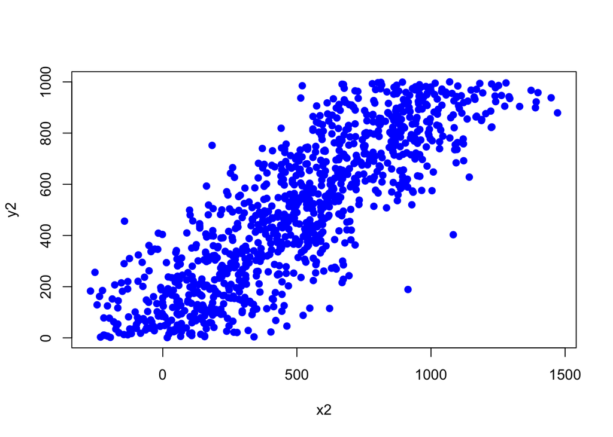

```r
x2=1:1000+rnorm(1000,mean=0,sd=200)
y2=1:1000
plot(x2,y2,pch=19,col="blue")
```

If you use smoothScatter() function, you get the densities.

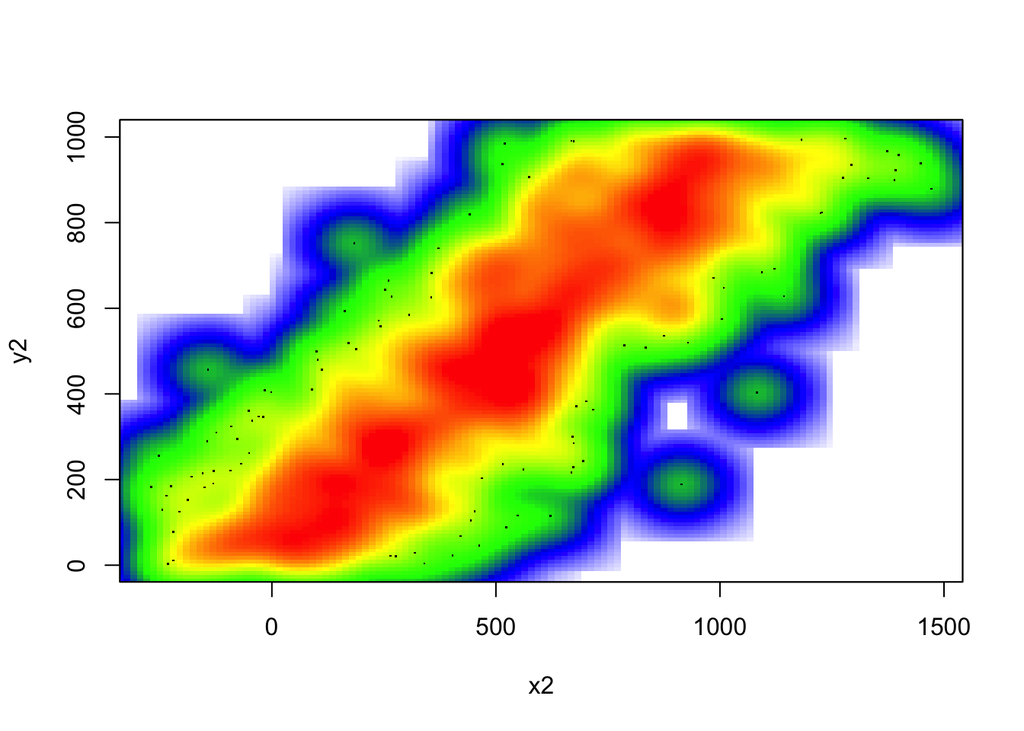

```r
smoothScatter(x2,y2,colramp=colorRampPalette(c("white","blue", "green","yellow","red")))
```

Now, plot with `colramp=heat.colors` argument and then use a custom color scale using the following argument.

```
colramp = colorRampPalette(c("white","blue", "green","yellow","red")))
```

# 6 Functions and control structures (for, if/else etc.)

## 6.1

Read CpG island data

```r
cpgi=read.table("../data/CpGi.table.hg18.txt",header=TRUE,sep="\t")
head(cpgi)
```

```
##   chrom chromStart chromEnd     name length cpgNum gcNum perCpg perGc
## 1  chr1      18598    19673 CpG: 116   1075    116   787   21.6  73.2
## 2  chr1     124987   125426  CpG: 30    439     30   295   13.7  67.2
## 3  chr1     317653   318092  CpG: 29    439     29   295   13.2  67.2
## 4  chr1     427014   428027  CpG: 84   1013     84   734   16.6  72.5
## 5  chr1     439136   440407  CpG: 99   1271     99   777   15.6  61.1
## 6  chr1     523082   523977  CpG: 94    895     94   570   21.0  63.7
##   obsExp
## 1   0.83
## 2   0.64
## 3   0.62
## 4   0.64
## 5   0.84
## 6   1.04
```

## 6.2

Check values at perGc column using a histogram. ‘perGc’ stands for GC percent => percentage of C+G nucleotides

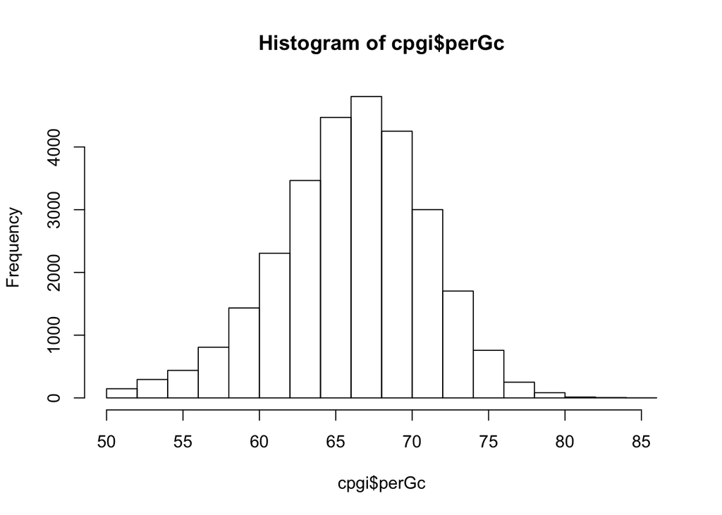

## 6.3

Make a boxplot for ‘perGc’ column

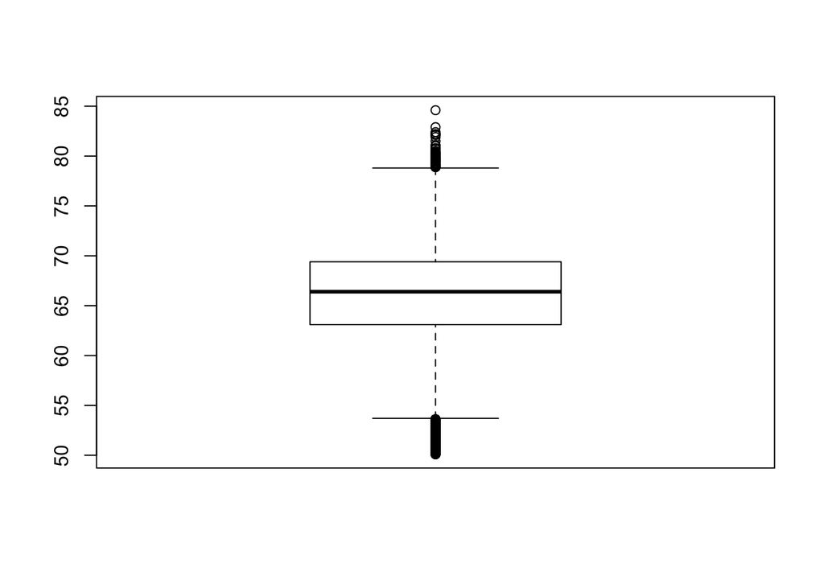

## 6.4

Use if/else structure to decide if given GC percent high, low or medium. If it is low, high, or medium. low < 60, high>75, medium is between 60 and 75 use greater or less than operators < or > . Fill in the values in the in code below, where it is written ‘YOU_FILL_IN’

```r
GCper=65
 #result="low"# set initial value

  if(GCper < 60){ # check if GC value is lower than 60, assign "low" to result
    result="low"
    cat("low")
  }
  else if(GCper > 75){  # check if GC value is higher than 75, assign "high" to result
    result="high"
    cat("high")
  }else{ # if those two conditions fail then it must be "medium"
    result="medium"
  }

result
```

## 6.5

Write a function that takes a value of GC percent and decides if it is low, high, or medium. low < 60, high>75, medium is between 60 and 75. Fill in the values in the in code below, where it is written ‘YOU_FILL_IN’

```
GCclass<-function(my.gc){

  YOU_FILL_IN

  return(result)
}
GCclass(10) # should return "low"
GCclass(90) # should return "high"
GCclass(65) # should return "medium"
```

## 6.6

Use a for loop to get GC percentage classes for gcValues below. Use the function you wrote above.

```
gcValues=c(10,50,70,65,90)
for( i in YOU_FILL_IN){
  YOU_FILL_IN
}
```

## 6.7

Use `lapply` to get to get GC percentage classes for gcValues. Example:

```r
vec=c(1,2,4,5)
power2=function(x){ return(x^2)  }
    lapply(vec,power2)
```

## 6.8

Use sapply to get values to get GC percentage classes for gcValues

## 6.9

Is there a way to decide on the GC percentage class of given vector of GCpercentages without using if/else structure and loops ? if so, how can you do it? **HINT:** subsetting using < and > operators